# Final Project

Group L

# Overview

For this project, we explored two datasets – tweets about Covid-19 vaccine and the reported side effects of it. Firstly, we looked into what people are discussing when they tweet about Covid-19 vaccine. Then we narrowed it down to the side effect discussions, to see what’s commonly mentioned here and where the tweets were sent. Secondly, we focused on the adverse reactions reported from 2020-12-01 to 2021-3-31. The visualization aims to provide an insight into who are the people reporting side effects and how do they compare to the general population; the most common reported symptoms etc. We also analyzed tweets associated with the covid-19 vaccine to see people’s attitudes on the vaccine.

# Data

- All COVID-19 Vaccines Tweets https://www.kaggle.com/gpreda/all-covid19-vaccines-tweets
- Vaccine Adverse Event Reporting System (VAERS)1 established by the Food and Drug Administration (FDA) and the Centers for Disease Control and Prevention (CDC) https://vaers.hhs.gov/data/datasets.html?
- Allocations of Covid-19 vaccines produced by Pfizer and Moderna into different States by CDC https://data.cdc.gov/Vaccinations/COVID-19-Vaccine-Distribution-Allocations- by-Juris/saz5-9hgg https://data.cdc.gov/Vaccinations/COVID-19-Vaccine-Distribution-Allocations- by-Juris/b7pe-5nws
- COVID-19 Vaccination Demographic Data. Vaccination by age. https://www.cdc.gov/coronavirus/2019-ncov/vaccines/distributing/demographics-vaccination-data.html
- State-by-state data on COVID-19 vaccinations in the United States https://ourworldindata.org/us-states-vaccinations

# Tweets about Covid-19 Vaccine

## What Do People Tweet about Covid-19 Vaccines ?

```r
library(dplyr)
library(tm)
library(stopwords)
library(tidytext)
library(wordcloud)
library(tidyverse)
library(hunspell)
library(data.table)
# library(RColorBrewer)

tweet <- fread("./tweet_data_QH/vaccination_all_tweets_ansi.csv")
```

```r
load("./tweet_data_QH/term_stemmed_all.RData")
```

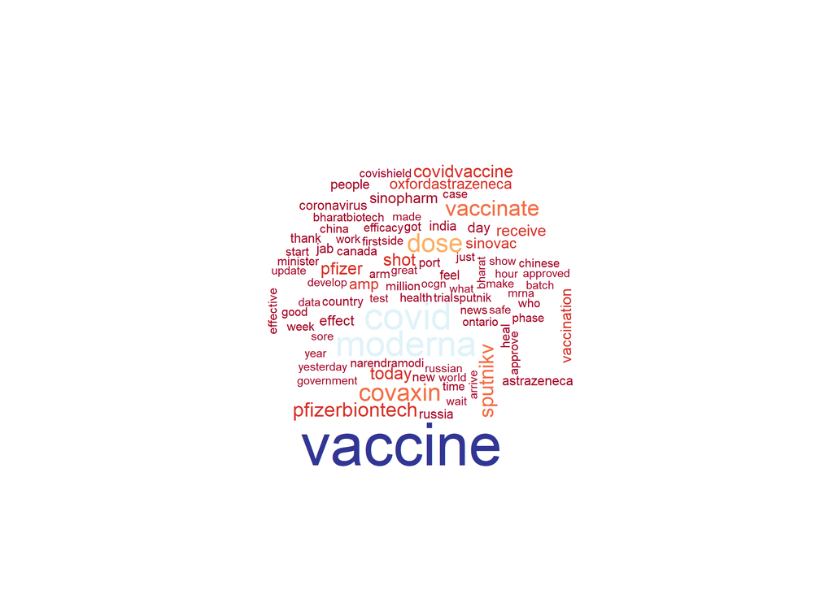

## A Co-occurrence Network of Keywords

```r
load("./tweet_data_QH/coocedge.Rdata")
load("./tweet_data_QH/uniquedges.Rdata")
```

[interactive chart not shown]

# Tweets about Covid-19 Vaccine’s Side Effects

## What Do They Tweet about Covid-19 Vaccine’s Side Effects ?

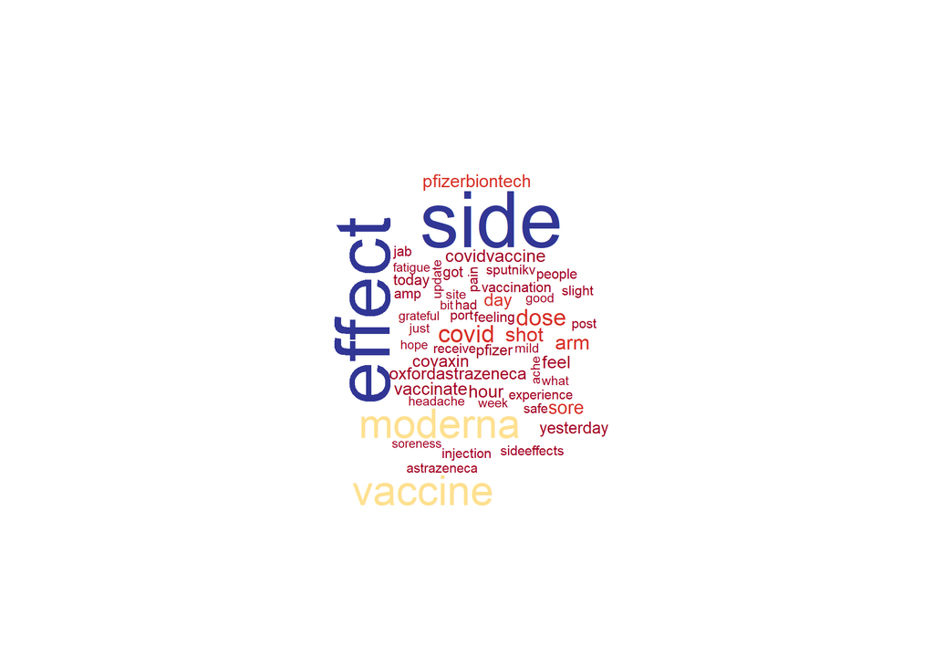